# CP_01_v01_NBA

## Todo list

- Read Data
- Summarise Data
- EDA
- Select best regession Model
- Estimated final model
- Forecast final model
- Regularization

# Libraries and functions

```r
library(here)
library(tidyverse)
library(skimr) # Beautiful Summarize
library(magrittr) # Pipe operators
```

```r
library(corrplot) # Correlations
library(ggcorrplot)  # Correlations
library(PerformanceAnalytics) # Correlations
library(leaps) # Model selection
library(caret) # Cross Validation
library(bestglm) # Cross Validation
library(glmnet) # Regularization
```

# Read Data

```r
raw_data <-  read.csv(here("CP_NBA/data","nba.csv"))
```

# Summarize Data

```r
skim(raw_data)
```

```
## Skim summary statistics
##  n obs: 485
##  n variables: 28
##
## Variable type: factor
##     variable missing complete   n n_unique
##  NBA_Country       0      485 485       44
##       Player       0      485 485      483
##           Tm       0      485 485       31
##                          top_counts ordered
##   USA: 374, Can: 12, Fra: 9, Aus: 8   FALSE
##      Kay: 3, Aar: 1, Aar: 1, Aar: 1   FALSE
##  TOT: 55, DAL: 18, MEM: 17, UTA: 17   FALSE
##
## Variable type: integer
##         variable missing complete   n       mean         sd    p0     p25
##              Age       0      485 485      26.26       4.27    19      23
##                G       0      485 485      50.17      24.87     1      29
##               MP       0      485 485    1154.14     811.36     1     381
##  NBA_DraftNumber       0      485 485      29.45      21.13     1      11
##           Salary       0      485 485 6636507.5  7392601.91 46080 1471382
##   median   p75       p100     hist
##       26    29   41       ▃▇▇▆▂▁▁▁
##       59    71   79       ▃▂▂▂▁▃▅▇
##     1134  1819 2898       ▇▃▅▃▅▅▂▂
##       25    47   62       ▇▆▅▃▃▂▁▇
##  3202217 1e+07    3.5e+07 ▇▂▁▁▁▁▁▁
##
## Variable type: numeric
##  variable missing complete   n  mean   sd     p0   p25 median   p75   p100
##      AST.       0      485 485 12.95 9.11   0     6.9   9.9   17.6   49.4
##      BLK.       0      485 485  1.71 1.68   0     0.6   1.2    2.2   13.4
##       BPM       0      485 485 -1.76 5.66 -49.2  -3.6  -1.3    0.5   54.4
##      DBPM       0      485 485 -0.49 2.39 -14.3  -1.7  -0.4    1      6.8
##      DRB.       0      485 485 14.95 6.85   0    10.2  14     18.8   37.6
##       DWS       0      485 485  1.18 1.03   0     0.3   1      1.8    5.6
##       FTr       2      483 485  0.26 0.29   0     0.15  0.23   0.32   5.33
##      OBPM       0      485 485 -1.27 5.03 -36.5  -2.7  -1.1    0.4   68.7
##      ORB.       0      485 485  4.87 4.58   0     1.8   3.2    7     35.9
##       OWS       0      485 485  1.28 1.88  -2.3   0     0.8    2     11.4
```

[output cut: 16 more lines]

```
##  ▇▅▃▂▁▁▁▁
##  ▇▁▁▁▁▁▁▁
##  ▁▁▇▁▁▁▁▁
##  ▇▃▂▁▁▁▁▁
##  ▁▇▃▁▁▁▁▁
##  ▁▁▇▁▁▁▁▁
##  ▇▆▁▁▁▁▁▁
##  ▂▇▂▁▁▁▁▁
##  ▁▇▇▅▃▂▁▁
##  ▁▁▇▅▁▁▁▁
##  ▁▁▇▇▃▂▁▁
##  ▅▇▂▁▁▁▁▁
##  ▇▆▅▂▁▁▁▁
##  ▁▁▇▁▁▁▁▁
##  ▇▃▇▇▃▂▁▁
```

- **Hay dos datos repetidos y varios NA**

# Data Wrangling data

- Data wrangling is the process of cleaning and unifying complex data sets for analysis, in turn boosting productivity within an organization.

```r
# delete duplicate
# Remove duplicate rows of the dataframe
raw_data %<>% distinct(Player,.keep_all= TRUE)

# delete NA's
raw_data %<>% drop_na()

# Summarise
skim(raw_data)
```

```
## Skim summary statistics
##  n obs: 481
##  n variables: 28
##
## Variable type: factor
##     variable missing complete   n n_unique
##  NBA_Country       0      481 481       44
##       Player       0      481 481      481
##           Tm       0      481 481       31
##                          top_counts ordered
##   USA: 370, Can: 12, Fra: 9, Aus: 8   FALSE
##      Aar: 1, Aar: 1, Aar: 1, Abd: 1   FALSE
##  TOT: 54, DAL: 18, MEM: 17, UTA: 17   FALSE
##
## Variable type: integer
##         variable missing complete   n       mean         sd    p0     p25
##              Age       0      481 481      26.29       4.27    19      23
##                G       0      481 481      50.52      24.67     1      30
##               MP       0      481 481    1163.17     808.61     1     391
##  NBA_DraftNumber       0      481 481      29.29      21.1      1      10
##           Salary       0      481 481 6682859.45 7405536.17 46080 1471382
##   median   p75       p100     hist
##       26    29   41       ▃▇▇▆▂▁▁▁
##       59    71   79       ▃▂▂▂▁▃▅▇
##     1155  1830 2898       ▇▅▅▃▅▅▃▂
##       24    47   62       ▇▆▅▃▃▂▁▇
##  3290000 1e+07    3.5e+07 ▇▂▂▁▁▁▁▁
##
## Variable type: numeric
##  variable missing complete   n   mean   sd     p0    p25 median   p75
##      AST.       0      481 481 12.96  9.09   0     6.9    9.9   17.2
##      BLK.       0      481 481  1.72  1.69   0     0.6    1.2    2.2
##       BPM       0      481 481 -1.7   5.64 -49.2  -3.5   -1.2    0.6
##      DBPM       0      481 481 -0.48  2.39 -14.3  -1.6   -0.4    1
##      DRB.       0      481 481 15.03  6.8    0    10.3   14     18.8
##       DWS       0      481 481  1.19  1.03   0     0.3    1      1.8
##       FTr       0      481 481  0.26  0.3    0     0.15   0.23   0.32
##      OBPM       0      481 481 -1.22  5.02 -36.5  -2.6   -1      0.4
##      ORB.       0      481 481  4.91  4.58   0     1.8    3.3    7.1
##       OWS       0      481 481  1.29  1.88  -2.3   0      0.8    2
```

[output cut: 16 more lines]

```
##    5.6  ▇▅▃▂▁▁▁▁
##    5.33 ▇▁▁▁▁▁▁▁
##   68.7  ▁▁▇▁▁▁▁▁
##   35.9  ▇▃▂▁▁▁▁▁
##   11.4  ▁▇▃▁▁▁▁▁
##  134.1  ▁▁▇▁▁▁▁▁
##   12.5  ▇▆▁▁▁▁▁▁
##   66.7  ▂▇▂▁▁▁▁▁
##   26.5  ▁▇▇▅▃▂▁▁
##    1.5  ▁▁▇▅▁▁▁▁
##   45.1  ▁▅▇▅▂▁▁▁
##    8.6  ▅▇▂▁▁▁▁▁
##   15    ▇▆▅▂▁▁▁▁
##    2.71 ▁▁▇▁▁▁▁▁
##    1    ▇▃▆▇▃▂▁▁
```

# EDA

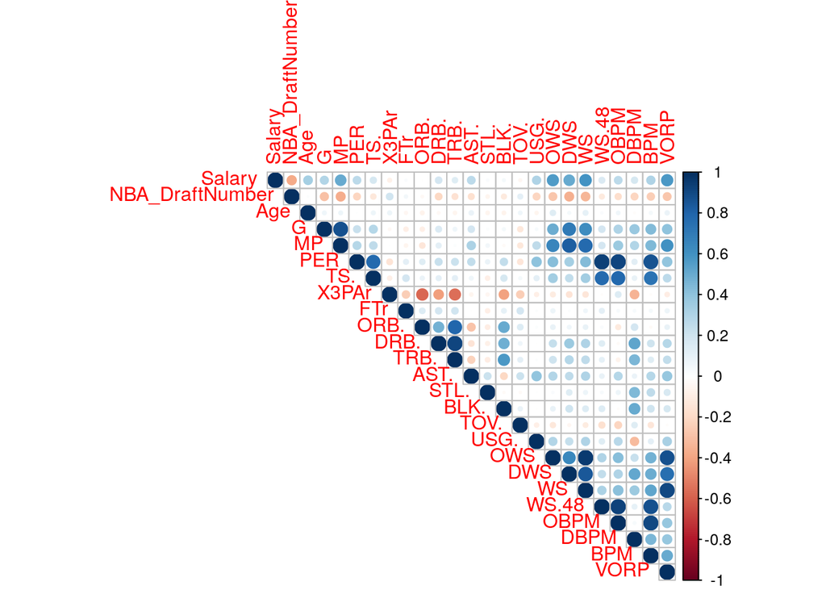

```r
# Excluded vars (factor)
vars <- c("Player","NBA_Country","Tm")


# Correlations
corrplot(cor(raw_data %>%
               select_at(vars(-vars)),
             use = "complete.obs"),
         method = "circle",type = "upper")
```

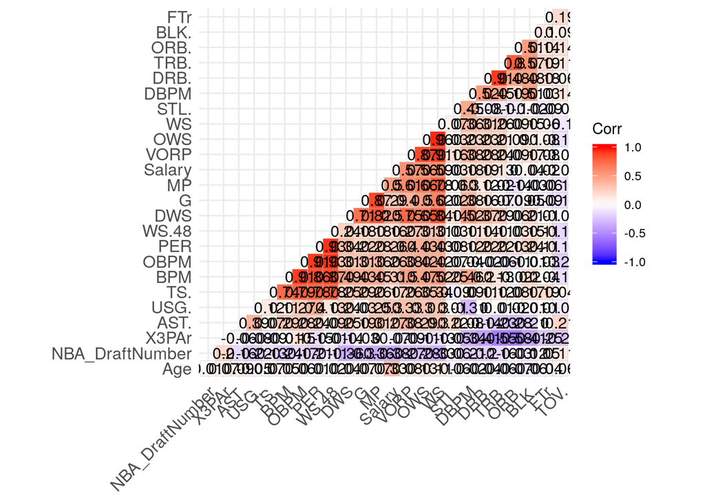

```r
# Other Correlations


ggcorrplot(cor(raw_data %>%
               select_at(vars(-vars)),
            use = "complete.obs"),
            hc.order = TRUE,
            type = "lower",  lab = TRUE)
```

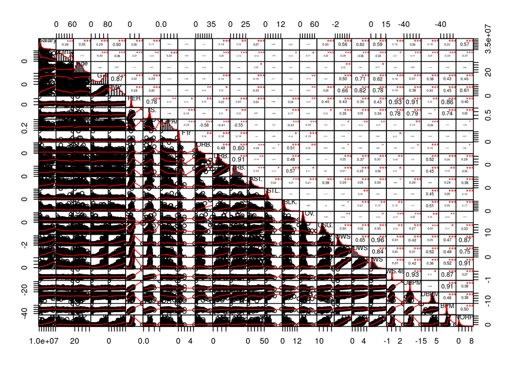

```r
# Other Correlations

chart.Correlation(raw_data %>%
               select_at(vars(-vars)),
               histogram=TRUE, pch=19)
```

## Log salary

```r
log_data <- raw_data %>% mutate(Salary=log(Salary))

skim(log_data)
```

```
## Skim summary statistics
##  n obs: 481
##  n variables: 28
##
## Variable type: factor
##     variable missing complete   n n_unique
##  NBA_Country       0      481 481       44
##       Player       0      481 481      481
##           Tm       0      481 481       31
##                          top_counts ordered
##   USA: 370, Can: 12, Fra: 9, Aus: 8   FALSE
##      Aar: 1, Aar: 1, Aar: 1, Abd: 1   FALSE
##  TOT: 54, DAL: 18, MEM: 17, UTA: 17   FALSE
##
## Variable type: integer
##         variable missing complete   n    mean     sd p0 p25 median  p75
##              Age       0      481 481   26.29   4.27 19  23     26   29
##                G       0      481 481   50.52  24.67  1  30     59   71
##               MP       0      481 481 1163.17 808.61  1 391   1155 1830
##  NBA_DraftNumber       0      481 481   29.29  21.1   1  10     24   47
##  p100     hist
##    41 ▃▇▇▆▂▁▁▁
##    79 ▃▂▂▂▁▃▅▇
##  2898 ▇▅▅▃▅▅▃▂
##    62 ▇▆▅▃▃▂▁▇
##
## Variable type: numeric
##  variable missing complete   n   mean   sd     p0    p25 median   p75
##      AST.       0      481 481 12.96  9.09   0     6.9    9.9   17.2
##      BLK.       0      481 481  1.72  1.69   0     0.6    1.2    2.2
##       BPM       0      481 481 -1.7   5.64 -49.2  -3.5   -1.2    0.6
##      DBPM       0      481 481 -0.48  2.39 -14.3  -1.6   -0.4    1
##      DRB.       0      481 481 15.03  6.8    0    10.3   14     18.8
##       DWS       0      481 481  1.19  1.03   0     0.3    1      1.8
##       FTr       0      481 481  0.26  0.3    0     0.15   0.23   0.32
##      OBPM       0      481 481 -1.22  5.02 -36.5  -2.6   -1      0.4
##      ORB.       0      481 481  4.91  4.58   0     1.8    3.3    7.1
##       OWS       0      481 481  1.29  1.88  -2.3   0      0.8    2
##       PER       0      481 481 13.36  8.74 -41.1   9.9   13.3   16.6
##    Salary       0      481 481 14.95  1.49  10.74 14.2   15.01  16.12
```

[output cut: 16 more lines]

```
##    5.33 ▇▁▁▁▁▁▁▁
##   68.7  ▁▁▇▁▁▁▁▁
##   35.9  ▇▃▂▁▁▁▁▁
##   11.4  ▁▇▃▁▁▁▁▁
##  134.1  ▁▁▇▁▁▁▁▁
##   17.36 ▂▁▁▂▇▅▅▃
##   12.5  ▇▆▁▁▁▁▁▁
##   66.7  ▂▇▂▁▁▁▁▁
##   26.5  ▁▇▇▅▃▂▁▁
##    1.5  ▁▁▇▅▁▁▁▁
##   45.1  ▁▅▇▅▂▁▁▁
##    8.6  ▅▇▂▁▁▁▁▁
##   15    ▇▆▅▂▁▁▁▁
##    2.71 ▁▁▇▁▁▁▁▁
##    1    ▇▃▆▇▃▂▁▁
```

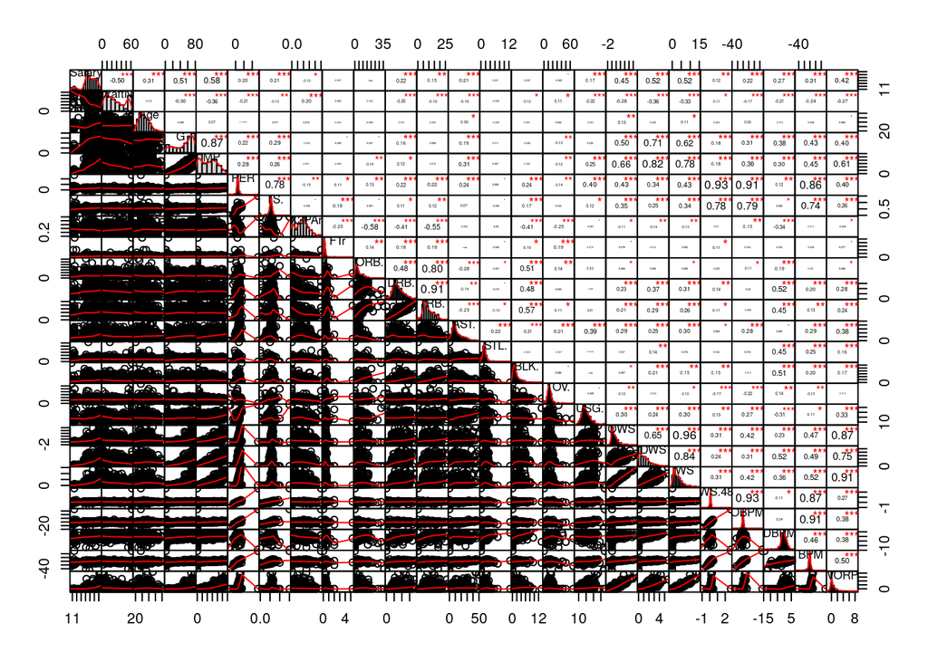

```r
chart.Correlation(log_data %>%
               select_at(vars(-vars)),
               histogram=TRUE, pch=19)
```

# Model Selection

```r
nba <- raw_data %>% select_at(vars(-vars))


model_select <- regsubsets(Salary~. , data =nba, method = "seqrep",nvmax=24)

model_select_summary <- summary(model_select)

data.frame(
  Adj.R2 = (model_select_summary$adjr2),
  CP = (model_select_summary$cp),
  BIC = (model_select_summary$bic)
)
```

```
##       Adj.R2           CP       BIC
## 1  0.3468829 178.99531545 -193.5568
## 2  0.4199111 106.42889645 -245.4208
## 3  0.4654188  61.69512923 -279.5489
## 4  0.4897104  38.32828743 -296.7515
## 5  0.5251353   3.97438461 -326.1944
## 6  0.5290257   1.11190295 -324.9892
## 7  0.5311445   0.02289633 -321.9979
## 8  0.5317427   0.44764777 -317.4541
## 9  0.5310863   2.11410760 -311.6246
## 10 0.5311622   3.05605429 -306.5489
## 11 0.5312582   3.97854770 -301.4960
## 12 0.5305737   5.66738722 -295.6449
## 13 0.5297086   7.53017760 -289.6123
## 14 0.5002931  37.28730796 -255.2856
## 15 0.5312492   8.05569732 -280.9033
## 16 0.5000898  39.38942216 -244.8071
## 17 0.5297642  11.53162036 -269.1034
## 18 0.5288153  13.46479612 -262.9979
## 19 0.5280448  15.22160254 -257.0784
## 20 0.5204254  23.58143413 -244.2436
## 21 0.5261607  19.05570378 -244.9016
## 22 0.5240550  22.08445788 -237.6419
## 23 0.5241389  23.00604438 -232.6022
## 24 0.5231016  25.00000000 -226.4327
```

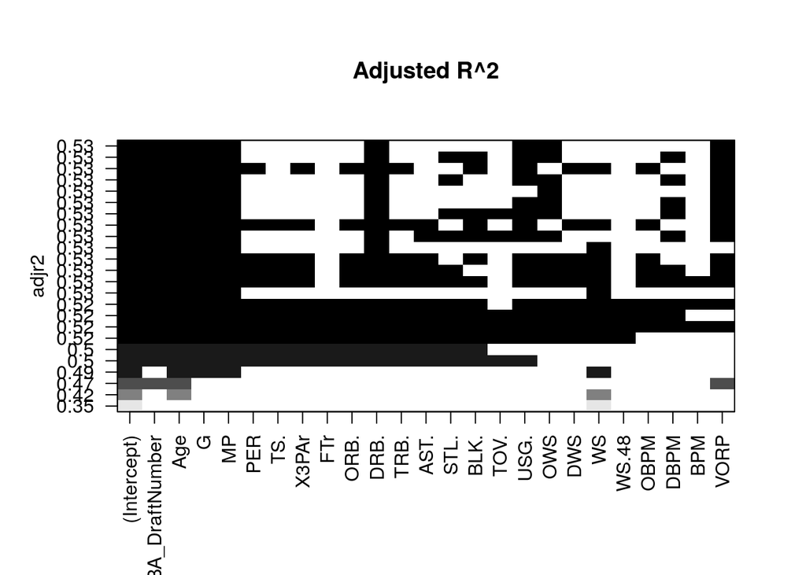

```r
plot(model_select, scale = "adjr2", main = "Adjusted R^2")
```

```r
data.frame(
  Adj.R2 = which.max(model_select_summary$adjr2),
  CP = which.min(model_select_summary$cp),
  BIC = which.min(model_select_summary$bic)
)
```

```
##   Adj.R2 CP BIC
## 1      8  7   5
```

**“All models are wrong, some models are useful”, Box, G.E.P**

## Solution: Cross Validation

http://www.sthda.com/english/articles/37-model-selection-essentials-in-r/155-best-subsets-regression-essentials-in-r/

### Using Caret

```r
# get_model_formula(), allowing to access easily the formula of the models returned by the function regsubsets(). Copy and paste the following code in your R console:
# id: model id
# object: regsubsets object
# data: data used to fit regsubsets
# outcome: outcome variable
get_model_formula <- function(id, object, outcome){
  # get models data
  models <- summary(object)$which[id,-1]
  # Get model predictors
  predictors <- names(which(models == TRUE))
  predictors <- paste(predictors, collapse = "+")
  # Build model formula
  as.formula(paste0(outcome, "~", predictors))
}



# get_cv_error(), to get the cross-validation (CV) error for a given model:
get_cv_error <- function(model.formula, data, kfold=5, setseed=1){
  set.seed(setseed)
  train.control <- trainControl(method = "cv",
                                number = kfold)
  cv <- train(model.formula,
              data = data, method = "lm",
              trControl = train.control)
  cv$results$RMSE
}


# Compute cross-validation error
model.ids <- c(8,7,5)
cv.errors <-  map(model.ids, get_model_formula,model_select , "Salary") %>%
  map(get_cv_error, data = nba,kfold=10,setseed=12345) %>%
  unlist()
cv.errors
```

```
## [1] 5098235 5099926 5109550
```

```r
# Select the model that minimize the CV error
which.min(cv.errors)
```

```
## [1] 1
```

```r
coef(model_select, model.ids[which.min(cv.errors)])
```

```
##     (Intercept) NBA_DraftNumber             Age               G
##    -8408758.105      -66715.393      523186.811     -141244.778
##              MP            DRB.            USG.             OWS
##        5742.975       98662.628       57892.757      462285.749
##            VORP
##      944618.867
```

```r
# all sample
summary(lm(get_model_formula (model.ids[which.min(cv.errors)], model_select, "Salary"),data=nba))
```

```
##
## Call:
## lm(formula = get_model_formula(model.ids[which.min(cv.errors)],
##     model_select, "Salary"), data = nba)
##
## Residuals:
##       Min        1Q    Median        3Q       Max
## -15431121  -3007670   -347579   2148060  21556190
##
## Coefficients:
##                   Estimate Std. Error t value Pr(>|t|)
## (Intercept)     -8408758.1  2031630.1  -4.139 4.13e-05 ***
## NBA_DraftNumber   -66715.4    12077.9  -5.524 5.49e-08 ***
## Age               523186.8    55047.0   9.504  < 2e-16 ***
## G                -141244.8    22279.5  -6.340 5.39e-10 ***
## MP                  5743.0      786.6   7.301 1.22e-12 ***
## DRB.               98662.6    37166.4   2.655  0.00821 **
## USG.               57892.8    45706.6   1.267  0.20592
## OWS               462285.7   266815.7   1.733  0.08382 .
## VORP              944618.9   406578.6   2.323  0.02059 *
## ---
## Signif. codes:  0 '***' 0.001 '**' 0.01 '*' 0.05 '.' 0.1 ' ' 1
##
## Residual standard error: 5068000 on 472 degrees of freedom
## Multiple R-squared:  0.5395, Adjusted R-squared:  0.5317
## F-statistic: 69.13 on 8 and 472 DF,  p-value: < 2.2e-16
```

### bestglm

bestglm(Xy, family = gaussian, IC = “BIC”, t = “default”, CVArgs = “default”, qLevel = 0.99, TopModels = 5, method = “exhaustive”, intercept = TRUE, weights = NULL, nvmax = “default”, RequireFullEnumerationQ = FALSE, …)

```r
# bestglm dataframe Xy
nba %>% dplyr::select(-Salary,Salary) -> nba_bestglm


# 10 kfolds
model_bestglm <-
    bestglm(Xy = nba_bestglm,
            family = gaussian,
            IC = "CV",
             method = "exhaustive",
            CVArgs=list(Method="HTF", K=10, REP=1))

model_bestglm$BestModel
```

```
##
## Call:
## lm(formula = y ~ ., data = data.frame(Xy[, c(bestset[-1], FALSE),
##     drop = FALSE], y = y))
##
## Coefficients:
##     (Intercept)  NBA_DraftNumber              Age                G
##        -5286728           -71999           506945          -157002
##              MP               WS
##            5319          1007154
```

```r
summary(model_bestglm$BestModel)
```

```
##
## Call:
## lm(formula = y ~ ., data = data.frame(Xy[, c(bestset[-1], FALSE),
##     drop = FALSE], y = y))
##
## Residuals:
##       Min        1Q    Median        3Q       Max
## -15157386  -2948902   -410269   2227293  22105518
##
## Coefficients:
##                 Estimate Std. Error t value Pr(>|t|)
## (Intercept)     -5286728    1569634  -3.368 0.000818 ***
## NBA_DraftNumber   -71999      11916  -6.042 3.07e-09 ***
## Age               506945      54915   9.231  < 2e-16 ***
## G                -157002      19602  -8.010 8.96e-15 ***
## MP                  5319        752   7.073 5.47e-12 ***
## WS               1007154     142463   7.070 5.58e-12 ***
## ---
## Signif. codes:  0 '***' 0.001 '**' 0.01 '*' 0.05 '.' 0.1 ' ' 1
##
## Residual standard error: 5103000 on 475 degrees of freedom
## Multiple R-squared:  0.5301, Adjusted R-squared:  0.5251
## F-statistic: 107.2 on 5 and 475 DF,  p-value: < 2.2e-16
```

```r
# LOOCV

model_bestglm2 <-
    bestglm(Xy = nba_bestglm,
            family = gaussian,
            IC="LOOCV",
            t=10,
             method = "exhaustive")

model_bestglm2$BestModel
```

```
##
## Call:
## lm(formula = y ~ ., data = data.frame(Xy[, c(bestset[-1], FALSE),
##     drop = FALSE], y = y))
##
## Coefficients:
##     (Intercept)  NBA_DraftNumber              Age                G
##        -3992141           -62904           512821          -159409
##              MP              PER            X3PAr             DRB.
##            5243          -325241         -2750041           159039
##            USG.               WS             OBPM
##          130296           842904           558688
```

```r
summary(model_bestglm2$BestModel)
```

```
##
## Call:
## lm(formula = y ~ ., data = data.frame(Xy[, c(bestset[-1], FALSE),
##     drop = FALSE], y = y))
##
## Residuals:
##       Min        1Q    Median        3Q       Max
## -15605495  -2941425   -424903   2326552  21883706
##
## Coefficients:
##                   Estimate Std. Error t value Pr(>|t|)
## (Intercept)     -3992141.0  2787529.5  -1.432  0.15277
## NBA_DraftNumber   -62903.5    12271.8  -5.126 4.34e-07 ***
## Age               512821.4    55127.4   9.302  < 2e-16 ***
## G                -159408.9    21637.7  -7.367 7.89e-13 ***
## MP                  5242.5      840.7   6.236 1.00e-09 ***
## PER              -325240.9   140976.9  -2.307  0.02149 *
## X3PAr           -2750040.9  1629692.9  -1.687  0.09218 .
## DRB.              159039.4    50877.1   3.126  0.00188 **
## USG.              130295.9    56682.5   2.299  0.02196 *
## WS                842903.7   160104.8   5.265 2.14e-07 ***
## OBPM              558688.1   239697.8   2.331  0.02019 *
## ---
## Signif. codes:  0 '***' 0.001 '**' 0.01 '*' 0.05 '.' 0.1 ' ' 1
##
## Residual standard error: 5065000 on 470 degrees of freedom
## Multiple R-squared:  0.5419, Adjusted R-squared:  0.5322
## F-statistic: 55.61 on 10 and 470 DF,  p-value: < 2.2e-16
```

# Regularization

http://www.sthda.com/english/articles/37-model-selection-essentials-in-r/153-penalized-regression-essentials-ridge-lasso-elastic-net/

Computing elastic net regession

The elastic net regression can be easily computed using the caret workflow, which invokes the glmnet package.

We use caret to automatically select the best tuning parameters alpha and lambda. The caret packages tests a range of possible alpha and lambda values, then selects the best values for lambda and alpha, resulting to a final model that is an elastic net model.

Here, we’ll test the combination of 10 different values for alpha and lambda. This is specified using the option tuneLength.

The best alpha and lambda values are those values that minimize the cross-validation error

```r
# Build the model
set.seed(45678)
model <- train(
  Salary ~., data = nba, method = "glmnet",
  trControl = trainControl("cv", number = 10),
  tuneLength = 10
)
# Best tuning parameter
model$bestTune
```

```
##    alpha   lambda
## 86   0.9 132707.1
```

```r
coef(model$finalModel, model$bestTune$lambda)
```

```
## 25 x 1 sparse Matrix of class "dgCMatrix"
##                            1
## (Intercept)     -8191996.879
## NBA_DraftNumber   -64016.440
## Age               492080.560
## G                 -91626.951
## MP                  4035.555
## PER                    .
## TS.                    .
## X3PAr                  .
## FTr                    .
## ORB.                   .
## DRB.               61596.254
## TRB.                   .
## AST.                   .
## STL.               -5333.965
## BLK.                   .
## TOV.                   .
## USG.               75268.331
## OWS               291861.191
## DWS                    .
## WS                137527.660
## WS.48                  .
## OBPM                   .
## DBPM                   .
## BPM                    .
## VORP             1137077.297
```

### Train, Validation and Test

```r
set.seed(6789)
training.samples <- nba$Salary %>%
  createDataPartition(p = 0.8, list = FALSE)
train.data  <- nba[training.samples, ]
test.data <- nba[-training.samples, ]



#Using caret package

#Setup a grid range of lambda values:
lambda <- 10^seq(-3, 3, length = 100)
#Compute ridge regression:
# Build the model
set.seed(45678)
ridge <- train(
  Salary ~., data = train.data, method = "glmnet",
  trControl = trainControl("cv", number = 10),
  tuneGrid = expand.grid(alpha = 0, lambda = lambda)
  )
# Model coefficients
coef(ridge$finalModel, ridge$bestTune$lambda)
```

```
## 25 x 1 sparse Matrix of class "dgCMatrix"
##                            1
## (Intercept)     -6339397.323
## NBA_DraftNumber   -66613.227
## Age               498532.498
## G                 -82635.884
## MP                  2890.900
## PER               -26417.161
## TS.             -1326306.284
## X3PAr            -629400.221
## FTr                76937.967
## ORB.              -43742.457
## DRB.               37005.865
## TRB.               45385.275
## AST.              -35347.667
## STL.             -194367.662
## BLK.             -212421.855
## TOV.                1123.884
## USG.              151113.535
## OWS               320543.731
## DWS               169777.120
## WS                221797.293
## WS.48           -2222952.276
## OBPM               65860.880
## DBPM              121257.000
## BPM                74802.770
## VORP              992023.452
```

```r
# Make predictions
predictions <- ridge %>% predict(test.data)
# Model prediction performance
data.frame(
  RMSE = RMSE(predictions, test.data$Salary),
  Rsquare = R2(predictions, test.data$Salary)
)
```

```
##      RMSE   Rsquare
## 1 4736487 0.6310895
```

```r
#Compute lasso regression:
# Build the model
set.seed(45678)
lasso <- train(
  Salary ~., data = train.data, method = "glmnet",
  trControl = trainControl("cv", number = 10),
  tuneGrid = expand.grid(alpha = 1, lambda = lambda)
  )
# Model coefficients
coef(lasso$finalModel, lasso$bestTune$lambda)
```

```
## 25 x 1 sparse Matrix of class "dgCMatrix"
##                            1
## (Intercept)     -5526691.418
## NBA_DraftNumber   -65754.383
## Age               529743.856
## G                -139871.169
## MP                  5451.915
## PER              -260106.543
## TS.              -144032.622
## X3PAr           -1653699.373
## FTr              -159242.788
## ORB.             -743999.356
## DRB.             -654115.017
## TRB.             1508564.418
## AST.              -39096.477
## STL.             -135339.646
## BLK.              -89327.379
## TOV.               -4159.719
## USG.              200934.894
## OWS              -609958.123
## DWS             -1303950.449
## WS                990406.734
## WS.48            3981572.061
## OBPM                   .
## DBPM              -27450.601
## BPM               302566.101
## VORP             1026305.337
```

```r
# Make predictions
predictions <- lasso %>% predict(test.data)
# Model prediction performance
data.frame(
  RMSE = RMSE(predictions, test.data$Salary),
  Rsquare = R2(predictions, test.data$Salary)
)
```

```
##      RMSE   Rsquare
## 1 4656805 0.6389062
```

```r
#Elastic net regression:
# Build the model
set.seed(45678)
elastic <- train(
  Salary ~., data = train.data, method = "glmnet",
  trControl = trainControl("cv", number = 10),
  tuneLength = 10
  )
# Model coefficients
coef(elastic$finalModel, elastic$bestTune$lambda)
```

```
## 25 x 1 sparse Matrix of class "dgCMatrix"
##                            1
## (Intercept)     -8256100.283
## NBA_DraftNumber   -65230.825
## Age               477415.599
## G                 -52373.466
## MP                  2560.382
## PER                    .
## TS.                    .
## X3PAr                  .
## FTr                    .
## ORB.                   .
## DRB.               36905.408
## TRB.                   .
## AST.                   .
## STL.                   .
## BLK.                   .
## TOV.                   .
## USG.              103925.202
## OWS               204721.241
## DWS                    .
## WS                119632.338
## WS.48                  .
## OBPM                   .
## DBPM                   .
## BPM                    .
## VORP             1348966.423
```

```r
# Make predictions
predictions <- elastic %>% predict(test.data)
# Model prediction performance
data.frame(
  RMSE = RMSE(predictions, test.data$Salary),
  Rsquare = R2(predictions, test.data$Salary)
)
```

```
##      RMSE   Rsquare
## 1 4841238 0.6235393
```

```r
#Comparing models performance:
#The performance of the different models - ridge, lasso and elastic net - can be easily compared using caret. The best model is defined as the one that minimizes the prediction error.

models <- list(ridge = ridge, lasso = lasso, elastic = elastic)
resamples(models) %>% summary( metric = "RMSE")
```

```
##
## Call:
## summary.resamples(object = ., metric = "RMSE")
##
## Models: ridge, lasso, elastic
## Number of resamples: 10
##
## RMSE
##            Min. 1st Qu.  Median    Mean 3rd Qu.    Max. NA's
## ridge   5006342 5270433 5458312 5531482 5810646 6118684    0
## lasso   4997326 5503295 5577094 5904964 5832209 8837858    0
## elastic 4531252 5062958 5253694 5335925 5588180 6175281    0
```